# Diagnosing Diseases using kNN

An Application of kNN to Diagnose Diabetes

Author

Elena Boiko, Jacqueline Razo (Advisor: Dr. Cohen)

Published

November 1, 2026

Slides: slides.html ( Go to `slides.qmd` to edit)

## Introduction

The k-Nearest-Neighbors (kNN) is an algorithm that is being used in a variety of fields to classify or predict data. The kNN algorithm is a simple algorithm that classifies data based on how similar a datapoint is to a class of datapoints. One of the benefits of using this algorithmic model is how simple it is to use and the fact it’s non-parametric which means it fits a wide variety of datasets. One drawback from using this model is that it does have a higher computational cost than other models which means that it doesn’t perform as well or fast on big data. Despite this, the model’s simplicity makes it easy to understand and easy to implement in a variety of fields. One such field is the field of healthcare where kNN models have been successfully used to predict diseases such as diabetes and hypertension. In this paper we will focus on the methodology and application of kNN models in the field of healthcare to predict diabetes, a pressing public health problem.

To better understand the role of kNN in healthcare applications, it is important to first review its theoretical foundations, the key factors affecting its performance, and recent advancements in optimizing kNN for large datasets and medical diagnosis, particularly for diabetes prediction.

#### Theoretical Background of kNN

kNNs are supervised learning algorithms that work by comparing a data point to other similar data points to label it. It works on the assumption that data points that are similar to each other must be close to each other. In the thesis (Zhang 2016), the author gave the reader an introduction to how kNN works and how to run a kNN model in R studio. He describes the methodology as assigning an unlabeled observation to a class by using labeled examples that are similar to it. It also describes the Euclidean distance equation which is the default distance equation that is used for kNNs. The author also describes the impact the k parameter has on the algorithm. The k parameter is the parameter that tells the model how many neighbors it will use when trying to classify a data point. Zhang recommends setting the k parameter equal to the square root of the number of observations in the training dataset.

Although Zhang’s recommendation to set the k parameter could be a great starting point, the thesis (Zhang et al. 2017) proposed the decision tree-assisted tuning to optimize k, significantly enhancing accuracy. The authors of this thesis propose using a training stage where we use a decision tree to select the ideal number of k values and thus make the kNN more efficient. The authors deployed and tested two more efficient kNN methods called kTree and the k*Tree methods. They found their method did reduce running costs and increased classification accuracy.

Another big impact on accuracy is the distance the model uses to classify neighbors. Although the euclidean distance is the default distance that is used in kNNs there are other distances that can be used. In the thesis (Kataria and Singh 2013) the authors compare different distances in classification algorithms with a focus on the kNN algorithm. It starts off explaining how the kNN algorithm uses the nearest k-neighbors in order to classify data points and then describes how the euclidean distance does this by putting a line segment between point a and point b and then measuring the distance using the euclidean distance formula. It moves on to describe the “cityblock” or taxican distance and describes it as “the sum of the length of the projections of the line segment”. It also describes the cosine distance and the correlation distance and then compares the performance of the default euclidean distance to the performance of using city block, cosine and correlation distances. In the end it found the euclidean distance was more efficient than the others in their observations.

Syriopoulos et al. (Syriopoulos et al. 2023) also reviewed distance metric selection, confirming that Euclidean distance remains the most effective choice for most datasets. However, alternative metrics like Mahalanobis distance can perform better for correlated features. The review emphasized that selecting the right metric is dataset-dependent, influencing classification accuracy.

#### Challenges in Scaling kNN for Large Datasets

While kNN is simple and effective, it struggles with computational inefficiency when working with large datasets since it must calculate distances for every new observation. This becomes a major challenge in big data, where the sheer volume of information makes traditional kNN methods slow and resource-intensive.

To address this, Deng et al. (Deng et al. 2016) proposed an improved approach called LC-kNN, which combines k-means clustering with kNN to speed up computations and enhance accuracy. By dividing large datasets into smaller clusters, their method reduces the number of distance calculations needed. After extensive testing, the authors found that LC-kNN consistently outperformed standard kNN, achieving higher accuracy and better efficiency. Their study highlights a key limitation of traditional kNN (without optimization, its performance significantly declines on big data) and offers an effective solution to improve its scalability.

Continuing and summarizing these ideas, Syriopoulos et al. (Syriopoulos et al. 2023) explored techniques for accelerating kNN computations, such as:

- Dimensionality reduction (e.g., PCA, feature selection) to reduce data complexity.
- Approximate Nearest Neighbor (ANN) methods to speed up distance calculations.
- Hybrid models combining kNN with clustering (e.g., LC-kNN) to improve efficiency.

This approach enhanced both speed and accuracy, making it a promising solution for handling large datasets. In addition, the study categorizes kNN modifications into local hyperplane methods, fuzzy-based models, weighting schemes, and hybrid approaches, demonstrating how these adaptations help tackle issues like class imbalance, computational inefficiency, and sensitivity to noise.

Another key challenge for kNN is its performance in high-dimensional datasets. The 2023 study by Syriopoulos et al. evaluates multiple nearest neighbor search algorithms such as kd-trees, ball trees, Locality-Sensitive Hashing (LSH), and graph-based search methods that enable kNN performance scaling for larger datasets through minimized distance calculations.

The enhancements to kNN have substantially increased its performance in terms of speed and accuracy which now allows it to better handle large-scale datasets. However, as Syriopoulos et al. primarily compile prior research rather than conducting empirical comparisons, further work is needed to evaluate these optimizations in real-world medical classification tasks.

#### kNN in Disease Prediction: Applications & Limitations

##### Disease Prediction with kNN

kNN has been widely used for diabetes classification and early detection. Ali et al. (Ali et al. 2020) tested six different kNN variants in MATLAB to classify blood glucose levels, finding that fine kNN was the most accurate. Their research highlights how optimizing kNN can improve classification performance, making it a valuable tool in healthcare.

In turn, Saxena et al. (Saxena et al. 2014) used kNN on a diabetes dataset and observed that increasing the number of neighbors (k) led to better accuracy, but only to a certain extent. In their MATLAB-based study, they found that using k = 3 resulted in 70% accuracy, while increasing k to 5 improved it to 75%. Both studies demonstrate how kNN can effectively classify diabetes, with accuracy depending on the choice of k and dataset characteristics. Ongoing research continues to refine kNN, making it a more efficient and reliable tool for medical applications.

Feature selection is another critical factor. Panwar et al. (Panwar et al. 2016) demonstrated that focusing on just BMI and Diabetes Pedigree Function improved accuracy, suggesting that simplifying feature selection enhances model performance. The study of Suriya and Muthu (Suriya and Muthu 2023) showed that kNN is a promising model for predicting type 2 diabetes, showing the highest accuracy on smaller datasets. The authors tested three datasets of varying sizes from 692 to 1853 rows and 9-22 dimensions to test the kNN algorithm’s performance and found that the larger dataset requires a higher k-value. Besides, PCA analysis to reduce dimensionality did not improve model performance. This suggests that simplifying the data doesn’t always lead to better results in diabetes prediction. The same findings about PCA influence on ML models implementation, and kNN in particular, showed in the research of Iparraguirre-Villanueva et al. (Iparraguirre-Villanueva et al. 2023). Also, they confirmed that kNN alone is not always the best choice. Authors compared kNN with Logistic Regression, Naïve Bayes, and Decision Trees. Their results showed that while kNN performed well on balanced datasets, it struggled when class imbalances existed. While PCA significantly reduced accuracy for all models, the SMOTE-preprocessed dataset demonstrated the highest accuracy for the k-NN model (79.6%), followed by BNB with 77.2%. This reveals the importance of correct preprocessing techniques in improving kNN model accuracy, especially when handling imbalanced datasets.

Khateeb & Usman (Khateeb and Usman 2017) extended kNN’s application to heart disease prediction, demonstrating that feature selection and data balancing techniques significantly impact accuracy. Their study showed that removing irrelevant features did not always improve performance, emphasizing the need for careful feature engineering in medical datasets.

##### kNN Beyond Prediction: Handling Missing Data

While kNN is widely known for classification, it also plays a key role in data preprocessing for medical machine learning. Altamimi et al. (Altamimi et al. 2024) explored kNN imputation as a method to handle missing values in medical datasets. Their study showed that applying kNN imputation before training a machine learning model significantly improved diabetes prediction accuracy - from 81.13% to 98.59%. This suggests that kNN is not only useful for disease classification but also for improving data quality and completeness in healthcare applications.

Traditional methods often discard incomplete records, but kNN imputation preserves valuable information, leading to more reliable model performance. However, Altamimi et al. (2024) also highlighted challenges such as computational costs and sensitivity to parameter selection, reinforcing the need for further optimization when applying kNN to large-scale medical datasets.

##### Comparing kNN Variants & Hybrid Approaches

Research indicate that kNN works well for diabetes prediction, but recent studies demonstrate it doesn’t consistently provide the best results. The study by Theerthagiri et al. (Theerthagiri et al. 2022) evaluated kNN against multiple machine learning models such as Naïve Bayes, Decision Trees, Extra Trees, Radial Basis Function (RBF), and Multi-Layer Perceptron (MLP) through analysis of the Pima Indians Diabetes dataset. The research indicated that kNN performed adequately but MLP excelled beyond all other algorithms achieving top accuracy at 80.68% and leading in AUC-ROC with an 86%. Despite its effectiveness in classification tasks, kNN’s primary limitation is its inability to compete with advanced models like neural networks when processing complex datasets.

In turn, Uddin et al.(Uddin et al. 2022) explored advanced kNN variants, including Weighted kNN, Distance-Weighted kNN, and Ensemble kNN. Their findings suggest that:

- Weighted kNN improved classification by assigning greater importance to closer neighbors.
- Ensemble kNN outperformed standard kNN in disease prediction but required additional computational resources.
- Performance was highly sensitive to the choice of distance metric and k value tuning.

Their findings suggest that kNN can be improved through modifications, but it remains highly sensitive to dataset size, feature selection, and distance metric choices. In large-scale healthcare applications, Decision Trees (DT) and ensemble models may offer better trade-offs between accuracy and efficiency. These studies highlight the ongoing debate over kNN’s role in medical classification - whether modifying kNN is the best approach or if other models, such as DT or ensemble learning, provide stronger performance for diagnosing diseases.

kNN continues to be a valuable tool in medical machine learning, offering simplicity and strong performance in classification tasks. However, as research shows, its effectiveness depends on proper feature selection, optimized k values, and preprocessing techniques like imputation. While kNN remains an interpretable and adaptable model, newer methods - such as ensemble learning and neural networks - often outperform it, particularly in large-scale datasets. For our capstone project, exploring feature selection, fine-tuning kNN’s settings, and comparing it to other algorithms could give us valuable insights into its strengths and limitations.

## Methods

The kNN algorithm is a nonparametric supervised learning algorithm that can be used for classification or regression problems (Syriopoulos et al. 2023). In classification, it works on the assumption that similar data is close to each other in distance. It classifies a datapoint by using the euclidean distance formula to find the nearest k data specified. Once these k data points have been found, the kNN assigns a category to the new datapoint based off the category with the majority of the data points that are similar (Zhang 2016). Figure 1 illustrates this methodology with two distinct classes of hearts and circles. The knn algorithm is attempting to classify the mystery figure represented by the red square. The k parameter is set to k=5 which means the algorithm will use the euclidean distance formula to find the 5 nearest neighbors illustrated by the green circle. From here the algorithm simply counts the number from each class and designates the class that represents the majority which in this case is a heart.

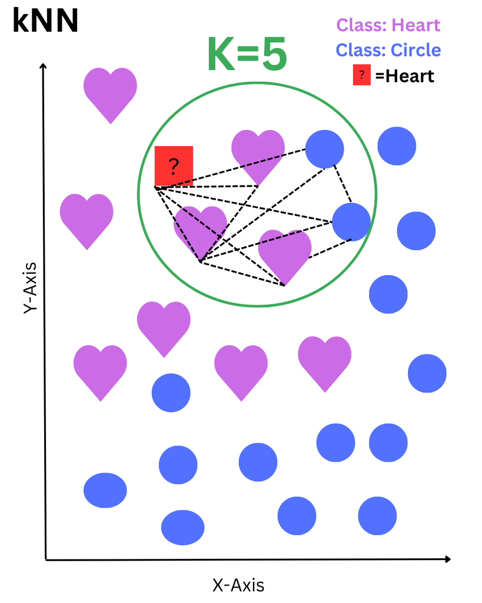

Figure 1. Visual Example of k-Nearest Neighbors (kNN) Classification with k = 5

The red square represents a data point to be classified. The algorithm selects the 5 nearest neighbors within the green circle—3 hearts and 2 circles. Based on the majority vote, the red square is classified as a heart.

### Classification process

#### The classification process has three distinct steps:

##### 1. Distance calculation

The kNN algorithm first calculates the distance between the data point it’s trying to classify and all the points in the training dataset. The most commonly used method is the **Euclidean distance** (Theerthagiri et al. 2022), which measures the straight-line distance between two points. The formula is:

$$d = \sqrt{(X_2 - X_1)^2 + (Y_2 - Y_1)^2}$$
Figure 2 shows the euclidean distance formula where $X_2 - X_1$ calculates the horizontal difference and $Y_2 - Y_1$ calculates the vertical difference. These two distances are then squared to ensure they are positive regardless of which directionality it has. Squaring the distances also gives greater emphasis to larger distances.

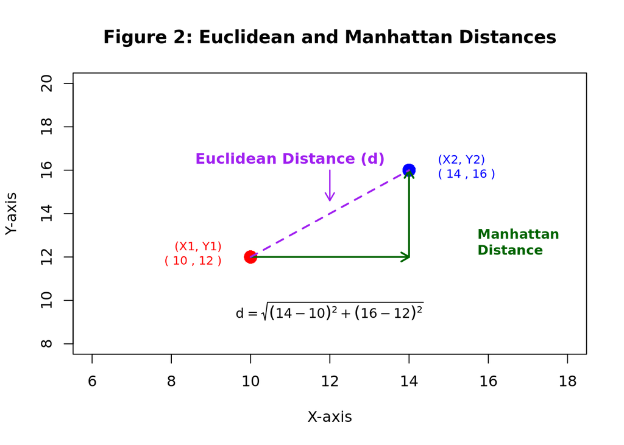

```r
library(ggplot2)

# Add points
X1 <- 10; Y1 <- 12
X2 <- 14; Y2 <- 16

# Create base plot
plot(c(X1, X2), c(Y1, Y2), type = "n",
     xlab = "X-axis", ylab = "Y-axis",
     main = "Figure 2: Euclidean and Manhattan Distances",
     xlim = c(X1 - 4, X2 + 4), ylim = c(Y1 - 4, Y2 + 4))

# Plot points
points(X1, Y1, col = "red", pch = 16, cex = 2)
points(X2, Y2, col = "blue", pch = 16, cex = 2)

# Add Manhattan path (green arrows)
arrows(X1, Y1, X2, Y1, col = "darkgreen", lwd = 2, length = 0.1)  # horizontal
arrows(X2, Y1, X2, Y2, col = "darkgreen", lwd = 2, length = 0.1)  # vertical

# Add Euclidean line (dashed purple)
segments(X1, Y1, X2, Y2, col = "purple", lwd = 2, lty = 2)

# Point labels
text(X1 - 0.5, Y1, labels = paste("(X1, Y1)\n(", X1, ",", Y1, ")"),
     col = "red", cex = 0.8, pos = 2)
text(X2 + 0.5, Y2, labels = paste("(X2, Y2)\n(", X2, ",", Y2, ")"),
     col = "blue", cex = 0.8, pos = 4)

# Euclidean distance label + arrow
text((X1 + X2)/2 - 1, (Y1 + Y2)/2 + 2.5, "Euclidean Distance (d)", col = "purple", font = 2, cex = 1)
arrows((X1 + X2)/2, (Y1 + Y2)/2 + 2, (X1 + X2)/2, (Y1 + Y2)/2 + 0.6,
       col = "purple", lwd = 1.5, length = 0.1)

# Manhattan label
text(X2 + 1.5, Y1 + 0.5, "Manhattan\nDistance", col = "darkgreen", font = 2, cex = 0.9, pos = 4)

# Euclidean distance formula
text(mean(c(X1, X2)), mean(c(Y1, Y2)) - 4.5,
     labels = expression(d == sqrt((14 - 10)^2 + (16 - 12)^2)),
     col = "black", cex = 0.9)
```

In some cases, **Manhattan distance** may be used instead. This metric calculates the total absolute difference across dimensions:

$$d = |X_2 - X_1| + |Y_2 - Y_1|$$

Unlike Euclidean distance, Manhattan distance follows a grid-like path (horizontal + vertical in Figure 2), making it more suitable for certain types of structured data or when outliers need to be minimized in influence (Aggarwal et al. 2015).

##### 2. Neighbor Selection

The kNN allows the selection of a parameter k that is used by the algorithm to choose how many neighbors will be used to classify the unknown datapoint. The k parameter is very important as a k parameter that is too large can lead to a classification problem caused by a majority of the samples creating a bias and causing underfitting. (Mucherino et al. 2009) A k being too small can cause the algorithm to be too sensitive to noise and outliers which can cause overfitting. Studies recommend using cross-validation or heuristic methods, such as setting k to the square root of the dataset size, to determine an optimal value (Syriopoulos et al. 2023).

##### 3. Classification decision based on majority voting

Once the k-nearest neighbors are identified, the algorithm assigns the new data point the most frequent class label among its neighbors. In cases of ties, distance-weighted voting can be applied, where closer neighbors have higher influence on the classification decision (Uddin et al. 2022).

### Assumptions

The k-Nearest Neighbors (kNN) algorithm operates under the assumption that data points with similar features exist in close proximity within the feature space and are therefore likely to belong to the same class (Boateng et al. 2020).

### Implementation of kNN

```r
library(DiagrammeR)

grViz("
digraph {
  graph [layout = dot, rankdir = LR, splines = true, size= 10]
  node [shape = box, style = rounded, fillcolor = lightblue, fontname = Arial, fontsize = 25, penwidth = 2]

  A [label = '1. Load Required Libraries',width=3, height=1.5]
  B [label = '2. Import & Explore Dataset',width=3, height=1.5]
  C [label = '3. Is preprocessing required?', shape = circle, fillcolor = lightblue, width=0.8, height=0.8, fontsize=25]
  D [label = '3a. Pre-Process the data',width=3, height=1.5]
  E [label = '4. Split Dataset into Training & Testing',width=3, height=1.5]
  F [label = '5. Hyperparameter tuning',width=3, height=1.5]
  G [label = '6. Train kNN Model',width=3, height=1.5]
  H [label = '7. Make Predictions',width=3, height=1.5]
  I [label = '8. Evaluate Model',width=3, height=1.5]

  A -> B
  B -> C
  C -> E [label = 'No', fontsize=25]
  C -> D [label = 'Yes', fontsize=25]
  D -> E
  E -> F
  F -> G
  G -> H
  H -> I

  #Edge Style
  edge [color = '#8B814C', arrowhead = vee, penwidth = 2]
}
")
```

[interactive chart not shown]

#### Pre-processing Data

Data must be prepared before implementing the kNN. In order for the kNN algorithm to work we need to handle missing values, make all values numeric and normalize or standardize the features. We also have the option of increasing accuracy by reducing dimensionality, removing correlated features and fixing class imbalance if we notice our data needs it.

1. **Handle missing values**: kNN’s work by calculating the distance between datapoints and missing values can skew the results. We must remove the missing values by either inputting them or dropping them.
2. **Make all values numeric**: kNN’s only handle numeric values so all categorical values must be encoded using either one-hot encoding or label encoding.
3. **Normalize or Standardize the features**: We must normalize or standardize the features to make sure we reduce bias. We can use the min-max scaler or the standard scaler to do this.
4. **Reduce dimensionality**: The kNN can struggle to calculate the distance between features if there are too many features. In order to solve this we can use Principal Component Analysis to reduce the number of features but keep the variance.
5. **Remove correlated features**: The kNN works best when there aren’t too many features, so we can use a correlation matrix to see which features we can drop. For example, it might be good to drop any features that have low variance or have a high correlation over 0.9 because this can be redundant.
6. **Fix class imbalance**: Class imbalances can lead to a bias. We noticed a class imbalance in our dataset and chose to use Synthetic Minority Over-sampling Technique(SMOTE) in order to handle the imbalance.

#### Hyperparameter Tuning

In order to increase the accuracy of the model there are a few parameters that we can adjust.

1. Find the optimal k parameter: We manually tested several k values and selected the one that provided the best balance of performance metrics
2. Change the distance metric: The kNN uses the euclidean distance by default but we can use the Manhattan distance, or another distance.
3. Weights: The kNN defaults to a “uniform” weight where it gives the same weight to all the distances but it can be adjusted to “distance” so that the closest neighbors have more weight.

### Advantages and Limitations

One of the advantages of the kNN is it’s easy to understand and implement. It is able to maintain great accuracy even with noisy data. (Syriopoulos et al. 2023). A serious limitation it has is the high computational cost and that it needs a large amount of memory to calculate the distance between all the datapoints.The kNN also has low accuracy with multidimensional data that has irrelevant features. (Saxena et al. 2014). Having to calculate the distance for all the datapoints can cause the knn to be slower when the number of datapoints gets too large as is the case with big data. The kNN takes a significant amount of time calculating the distances between at the datapoints in a big file. (Deng et al. 2016).

## Analysis and Results

### Data Exploration

We explored the [CDC Diabetes Health Indicators](https://archive.ics.uci.edu/dataset/891/cdc+diabetes+health+indicators.) dataset, sourced from the UC Irvine Machine Learning Repository. It is a set of data that was gathered by the Centers for Disease Control and Prevention (CDC) through the Behavioral Risk Factor Surveillance System (BRFSS), which is one of the biggest continuous health surveys in the United States.

The BRFSS is an annual telephone survey that has been ongoing since 1984 and each year, more than 400,000 Americans respond to the survey. It provides important data on health behaviors, chronic diseases, and preventive health care use to help researchers and policymakers understand the health status and risks of the public.

To transfer the data we used Python and the ucimlrepo package import the dataset directly from the UCI Machine Learning Repository, following the recommended instructions. This enabled us to easily save, prepare, and analyze the data in view of the current research.

```python
from ucimlrepo import fetch_ucirepo
import pandas as pd

# Fetch the dataset from UCI repository
cdc_data = fetch_ucirepo(id=891)

# Combine features and target into a single DataFrame
cdc_data_df = pd.concat([cdc_data.data.features, cdc_data.data.targets], axis=1)

# Save to CSV for R environment
cdc_data_df.to_csv("cdc_data.csv", index=False)
```

#### Data Composition

The dataset consists of **253,680** survey responses collected through the CDC Behavioral Risk Factor Surveillance System (BRFSS). It includes:

- **1 binary target variable**: Diabetes_binary
- **21 explanatory features** covering demographics, health conditions, lifestyle habits, and healthcare access.

This large-scale dataset is well-suited for modeling diabetes risk, providing a mix of binary, ordinal, and continuous variables.

The following table displays the first few rows of the CDC Diabetes Health Indicators dataset.

```r
library(readr)
library(knitr)

# Load dataset in R
cdc_data_df <- read_csv("cdc_data.csv", show_col_types = FALSE)
kable(head(cdc_data_df), caption = "Table 1. The First Few Rows of CDC Diabetes Dataset")
```

Table 1. The First Few Rows of CDC Diabetes Dataset

| HighBP | HighChol | CholCheck | BMI | Smoker | Stroke | HeartDiseaseorAttack | PhysActivity | Fruits | Veggies | HvyAlcoholConsump | AnyHealthcare | NoDocbcCost | GenHlth | MentHlth | PhysHlth | DiffWalk | Sex | Age | Education | Income | Diabetes_binary |
| --- | --- | --- | --- | --- | --- | --- | --- | --- | --- | --- | --- | --- | --- | --- | --- | --- | --- | --- | --- | --- | --- |
| 1 | 1 | 1 | 40 | 1 | 0 | 0 | 0 | 0 | 1 | 0 | 1 | 0 | 5 | 18 | 15 | 1 | 0 | 9 | 4 | 3 | 0 |
| 0 | 0 | 0 | 25 | 1 | 0 | 0 | 1 | 0 | 0 | 0 | 0 | 1 | 3 | 0 | 0 | 0 | 0 | 7 | 6 | 1 | 0 |
| 1 | 1 | 1 | 28 | 0 | 0 | 0 | 0 | 1 | 0 | 0 | 1 | 1 | 5 | 30 | 30 | 1 | 0 | 9 | 4 | 8 | 0 |
| 1 | 0 | 1 | 27 | 0 | 0 | 0 | 1 | 1 | 1 | 0 | 1 | 0 | 2 | 0 | 0 | 0 | 0 | 11 | 3 | 6 | 0 |
| 1 | 1 | 1 | 24 | 0 | 0 | 0 | 1 | 1 | 1 | 0 | 1 | 0 | 2 | 3 | 0 | 0 | 0 | 11 | 5 | 4 | 0 |
| 1 | 1 | 1 | 25 | 1 | 0 | 0 | 1 | 1 | 1 | 0 | 1 | 0 | 2 | 0 | 2 | 0 | 1 | 10 | 6 | 8 | 0 |

#### Feature Overview

The variables fall into *four types*, each encoded to preserve meaning and support distance-based modeling:

**1. Target Variable (1)**

- *Diabetes_binary*: Binary classification (0 = No diabetes, 1 = Diabetes/prediabetes)

**2. Binary Variables (14)**  
Encoded as 0 = No, 1 = Yes (except for Sex: 0 = Female, 1 = Male)

- *Health Conditions*: HighBP, HighChol, CholCheck, Stroke, HeartDiseaseorAttack
- *Lifestyle Factors*: Smoker, PhysActivity, Fruits, Veggies, HvyAlcoholConsump
- *Healthcare Access & Mobility*: AnyHealthcare, NoDocbcCost, DiffWalk, Sex

**3. Ordinal Variables (6)**  
Encoded using ranked integers to reflect meaningful progression:

- *Self-Reported Health*: GenHlth, MentHlth, PhysHlth
- *Demographics*: Age, Education, Income  
  (Higher values represent worse health or higher socioeconomic levels.)

**4. Continuous Variable (1)**

- *BMI*: Numeric value for Body Mass Index

The table below provides a detailed breakdown of variable types, descriptions, and value ranges.

```r
# Load necessary packages
library(knitr)

# Create a Data Frame with Variable Information
table_data <- data.frame(
  Type = c(
    "Target",
    "Binary", "", "", "", "", "", "", "", "", "", "", "", "", "",
    "Ordinal", "", "", "", "", "",
    "Continuous"
  ),
  Variable = c(
    "Diabetes_binary",
    "HighBP", "HighChol", "CholCheck", "Smoker", "Stroke", "HeartDiseaseorAttack",
    "PhysActivity", "Fruits", "Veggies", "HvyAlcoholConsump", "AnyHealthcare",
    "NoDocbcCost", "DiffWalk", "Sex",
    "GenHlth", "MentHlth", "PhysHlth", "Age", "Education", "Income",
    "BMI"
  ),
  Description = c(
    "Indicates whether a person has diabetes",
    "High Blood Pressure", "High Cholesterol", "Cholesterol check in the last 5 years",
    "Smoked at least 100 cigarettes in lifetime", "Had a stroke", "History of heart disease or attack",
    "Engaged in physical activity in the last 30 days", "Regular fruit consumption",
    "Regular vegetable consumption", "Heavy alcohol consumption", "Has health insurance or healthcare access",
    "Could not see a doctor due to cost", "Difficulty walking/climbing stairs", "Biological sex",
    "Self-reported general health (1=Excellent, 5=Poor)",
    "Number of mentally unhealthy days in last 30 days", "Number of physically unhealthy days in last 30 days",
    "Age Groups (1 = 18-24, ..., 13 = 80+)",
    "Highest education level (1 = No school, ..., 6 = College graduate)",
    "Household income category (1 = <$10K, ..., 8 = $75K+)",
    "Body Mass Index (BMI), measure of body fat"
  ),
  Range = c(
    "(0 = No, 1 = Yes)",
    "(0 = No, 1 = Yes)", "(0 = No, 1 = Yes)", "(0 = No, 1 = Yes)", "(0 = No, 1 = Yes)",
    "(0 = No, 1 = Yes)", "(0 = No, 1 = Yes)", "(0 = No, 1 = Yes)", "(0 = No, 1 = Yes)",
    "(0 = No, 1 = Yes)", "(0 = No, 1 = Yes)", "(0 = No, 1 = Yes)", "(0 = No, 1 = Yes)",
    "(0 = No, 1 = Yes)", "(0 = Female, 1 = Male)",
    "(1 = Excellent, ..., 5 = Poor)", "(0 - 30)", "(0 - 30)",
    "(1 = 18-24, ..., 13 = 80+)", "(1 = No school, ..., 6 = College grad)",
    "(1 = <$10K, ..., 8 = $75K+)", "(12 - 98)"
  )
)

# Print Table with knitr::kable()
kable(table_data, caption = "Table 2. Summary of Explanatory Variables", align = "l")
```

Table 2. Summary of Explanatory Variables

| Type | Variable | Description | Range |
| --- | --- | --- | --- |
| Target | Diabetes_binary | Indicates whether a person has diabetes | (0 = No, 1 = Yes) |
| Binary | HighBP | High Blood Pressure | (0 = No, 1 = Yes) |
|  | HighChol | High Cholesterol | (0 = No, 1 = Yes) |
|  | CholCheck | Cholesterol check in the last 5 years | (0 = No, 1 = Yes) |
|  | Smoker | Smoked at least 100 cigarettes in lifetime | (0 = No, 1 = Yes) |
|  | Stroke | Had a stroke | (0 = No, 1 = Yes) |
|  | HeartDiseaseorAttack | History of heart disease or attack | (0 = No, 1 = Yes) |
|  | PhysActivity | Engaged in physical activity in the last 30 days | (0 = No, 1 = Yes) |
|  | Fruits | Regular fruit consumption | (0 = No, 1 = Yes) |
|  | Veggies | Regular vegetable consumption | (0 = No, 1 = Yes) |
|  | HvyAlcoholConsump | Heavy alcohol consumption | (0 = No, 1 = Yes) |
|  | AnyHealthcare | Has health insurance or healthcare access | (0 = No, 1 = Yes) |
|  | NoDocbcCost | Could not see a doctor due to cost | (0 = No, 1 = Yes) |
|  | DiffWalk | Difficulty walking/climbing stairs | (0 = No, 1 = Yes) |
|  | Sex | Biological sex | (0 = Female, 1 = Male) |
| Ordinal | GenHlth | Self-reported general health (1=Excellent, 5=Poor) | (1 = Excellent, …, 5 = Poor) |
|  | MentHlth | Number of mentally unhealthy days in last 30 days | (0 - 30) |
|  | PhysHlth | Number of physically unhealthy days in last 30 days | (0 - 30) |
|  | Age | Age Groups (1 = 18-24, …, 13 = 80+) | (1 = 18-24, …, 13 = 80+) |
|  | Education | Highest education level (1 = No school, …, 6 = College graduate) | (1 = No school, …, 6 = College grad) |
|  | Income | Household income category (1 = <$10K, …, 8 = $75K+) | (1 = <$10K, …, 8 = $75K+) |
| Continuous | BMI | Body Mass Index (BMI), measure of body fat | (12 - 98) |

#### Data Integrity Assessment

In this step, we checked for null values, missing data (NaNs), and duplicate rows to ensure data integrity. Additionally, we identified columns with invalid values such as strings with spaces in numeric fields.

```r
library(knitr)
library(readr)

# Load the dataset
exploratory_df <- read_csv("eda.csv", show_col_types = FALSE)

# Print table with a new title (caption)
kable(exploratory_df, caption = "Table 3: Data Integrity Report")
```

Table 3: Data Integrity Report

| Data Quality Check | Count |
| --- | --- |
| Number of Nulls | 0 |
| Missing Data | 0 |
| Duplicate Rows | 24206 |
| Total Rows | 253680 |

There are no missing values, meaning no imputation is needed.

But 24,206 duplicate records were detected, which need to be analyzed to determine whether they need removal or weighting to prevent redundancy in model training.

### Exploratory Data Analysis (EDA)

To effectively prepare data for a distance-based model like k-Nearest Neighbors (kNN), it’s critical to understand the statistical properties of the features - including scale, variability, and the presence of outliers.

Figures 3 and 4 summarize the central tendencies and distributional characteristics of selected *ordinal* and *continuous* variables: *GenHlth, MentHlth, PhysHlth, Age, Education, Income, BMI*

#### Summary Statistics Heatmap

The heatmap below presents descriptive statistics for each variable, including mean, standard deviation, min/max, and quartiles.

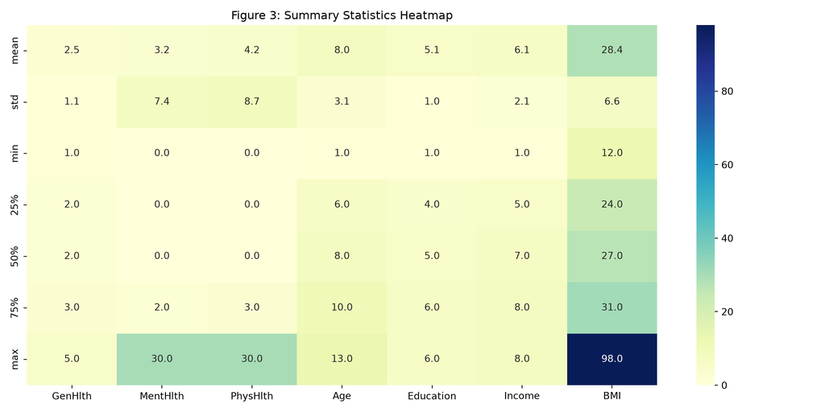

```python
import seaborn as sns
import matplotlib.pyplot as plt
import pandas as pd

# Select ordinal + continuous variables
summary_cols = ['GenHlth', 'MentHlth', 'PhysHlth', 'Age', 'Education', 'Income', 'BMI']

# Calculate statistics
summary_stats = cdc_data_df[summary_cols].describe().loc[['mean', 'std', 'min', '25%', '50%', '75%', 'max']]

# Plot heatmap
plt.figure(figsize=(12, 6))
sns.heatmap(summary_stats, annot=True, cmap="YlGnBu", fmt=".1f")
plt.title("Figure 3: Summary Statistics Heatmap")
plt.tight_layout()
plt.show()
```

- **BMI** stands out with the largest range (min = 12.0, max = 98.0) and a standard deviation of 6.6 - indicating significant variability.
- **MentHlth** and **PhysHlth** also show wide spreads (standard deviations of 7.4 and 8.7, respectively), reinforcing the need for scaling to prevent these features from dominating distance calculations.
- **Age** also shows moderate variability (std = 3.1), which may impact distance calculations if not scaled.
- **Ordinal features** like GenHlth, Education, and Income are on a much smaller scale (e.g., GenHlth: 1-5), which may cause them to be underweighted unless scaling is applied.

Because features like BMI, MentHlth, PhysHlth, and Age have larger numeric ranges, they can disproportionately influence distance metrics in kNN. This is why feature scaling is essential - it ensures that each feature contributes fairly when calculating similarity.

#### Outliers in Distribution

The boxplot below further illustrates value distributions and highlights extreme values:

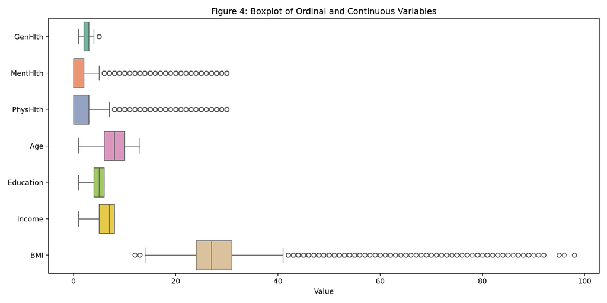

```python
import matplotlib.pyplot as plt
import seaborn as sns

# Select numeric ordinal and continuous variables
cols = ['GenHlth', 'MentHlth', 'PhysHlth', 'Age', 'Education', 'Income', 'BMI']

# Create boxplot
plt.figure(figsize=(12, 6))
sns.boxplot(data=cdc_data_df[cols], orient="h", palette="Set2")
plt.title("Figure 4: Boxplot of Ordinal and Continuous Variables")
plt.xlabel("Value")
plt.tight_layout()
plt.show()
```

**Notable Outliers:**

- **MentHlth** and **PhysHlth** exhibit outliers up to 30 — these may reflect long-term health issues but skew distributions.
- **BMI** has a wide distribution with extreme values approaching 98, which can affect both scaling and model sensitivity.

Outliers can mislead distance calculations, making certain data points appear abnormally close or far in feature space.

**Practical Steps for Preprocessing:**

| Problem | Solution |
| --- | --- |
| Scale imbalance | StandardScaler / MinMaxScaler |
| Outliers | RobustScaler / Clipping / Removal |
| Skewed features | Consider log or square root transform |

Applying these transformations ensures the distance metric used in kNN remains balanced and sensitive to meaningful differences across all feature dimensions.

#### Class Imbalance in Diabetes Prevalence

A critical issue in classification problems is *target class imbalance*. For our **Diabetes_binary** variable, the majority class (No Diabetes) comprises over 86% of the dataset, while the minority class (Diabetes/Prediabetes) represents only about 14%.

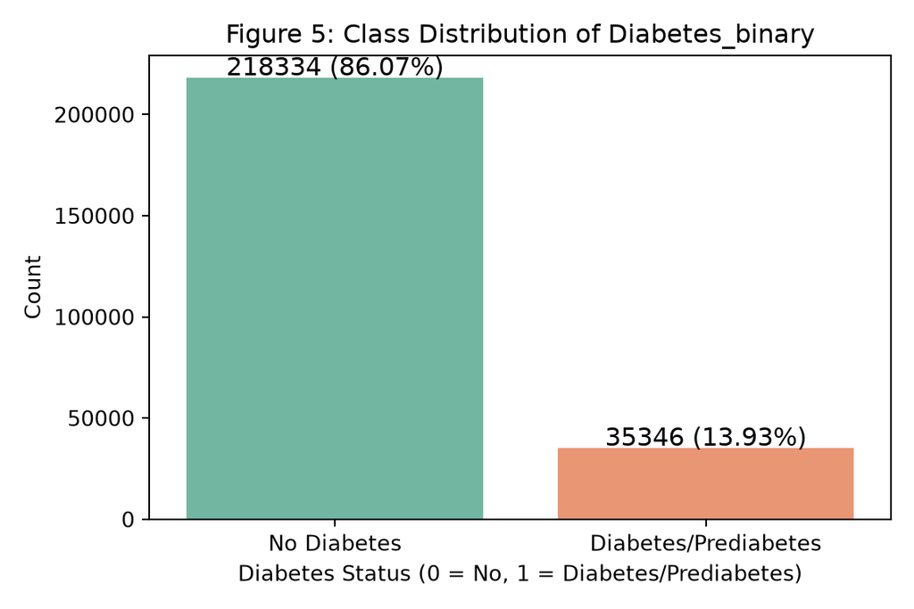

```python
def plot_class_distribution():
    import matplotlib.pyplot as plt
    import seaborn as sns

    target_variable = "Diabetes_binary"

    if target_variable in cdc_data_df.columns:
        class_counts = cdc_data_df[target_variable].value_counts()
        class_percentages = cdc_data_df[target_variable].value_counts(normalize=True) * 100

        plt.figure(figsize=(6, 4))
        ax = sns.barplot(x=class_counts.index, y=class_counts.values, palette="Set2")

        for i, value in enumerate(class_counts.values):
            percentage = class_percentages[i]
            ax.text(i, value + 1000, f"{value} ({percentage:.2f}%)", ha="center", fontsize=12)

        plt.title(f"Figure 5: Class Distribution of {target_variable}")
        plt.ylabel("Count")
        plt.xlabel("Diabetes Status (0 = No, 1 = Diabetes/Prediabetes)")
        plt.xticks([0, 1], ["No Diabetes", "Diabetes/Prediabetes"])
        plt.tight_layout()
        plt.show()

plot_class_distribution()
```

This imbalance can lead to biased model predictions, favoring the dominant class while under-detecting diabetes cases.

To handle this imbalance and improve classification performance, we can apply strategies such as oversampling the minority class (e.g., with SMOTE) or undersampling the majority class. Note that weights=‘distance’ in KNeighborsClassifier weights neighbors by distance, not by class, so it does not by itself correct class imbalance.

#### Correlation Analysis

To better understand how variables relate to each other - and to our target - we generated a correlation heatmap. This helps detect redundant features, multicollinearity, and potential predictors of diabetes.

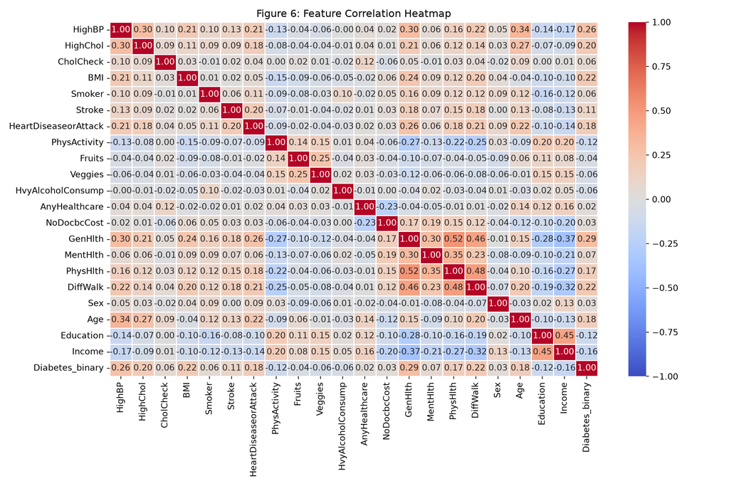

```python
import pandas as pd
import matplotlib.pyplot as plt
import seaborn as sns

corr_matrix = cdc_data_df.corr()

fig, ax = plt.subplots(figsize=(12, 8))
sns.heatmap(corr_matrix, ax=ax, annot=True, fmt=".2f", cmap="coolwarm", linewidths=0.5, vmin=-1, vmax=1)
ax.set_title("Figure 6: Feature Correlation Heatmap")
plt.tight_layout()
plt.show()
```

**Positive Correlations:**

• *General Health (GenHlth) is strongly correlated with Physical Health (PhysHlth)* (0.52) and *Difficulty Walking (DiffWalk)* (0.45).

As individuals report poorer general health, they experience more physical health issues and mobility limitations.

• *Physical Health (PhysHlth)* and *Difficulty Walking (DiffWalk)* (0.47) show a strong link. Those with more days of poor physical health are likely to struggle with mobility.

• *Age* correlates with *High Blood Pressure* (0.34) and *High Cholesterol* (0.27), indicating an increased risk of cardiovascular conditions as people get older.

• *Mental Health (MentHlth)* and *Physical Health (PhysHlth)* (0.34) are positively associated. Worsening mental health often coincides with physical health problems.

**Negative Correlations:**

The heatmap confirms well-known health trends: age, high blood pressure, and cholesterol are major risk factors for diabetes. Poor physical and mental health are strongly related, and socioeconomic status (income, education) plays a key role in overall health. These insights highlight the importance of early intervention strategies and lifestyle modifications to prevent chronic diseases like diabetes.

No pair of features exceeds a correlation of ±0.52, so **multicollinearity is not a concern**. No features need to be dropped due to redundancy.

These patterns support the need for early interventions and lifestyle-focused health strategies.

#### Age and BMI Density Analysis by Diabetes Status

Age and Body Mass Index (BMI) are both recognized as key risk factors for diabetes. To explore these relationships, we compared their distributions between individuals with and without diabetes.

**Age Distribution:**

Figure 7 illustrates the distribution of age categories for individuals with and without diabetes. Although age is represented as an ordinal variable (1-13, likely corresponding to increasing age groups), several trends are apparent:

[figure not shown]

```python
plt.figure(figsize=(10, 6))
sns.kdeplot(data=cdc_data_df, x="Age", hue="Diabetes_binary", fill=True,
            common_norm=False, palette={0: "#80cdc1", 1: "#d6604d"},
            alpha=0.4, linewidth=1.5)

plt.title("Figure 7: Age Density by Diabetes Status")
plt.xlabel("Age")
plt.ylabel("Density")
plt.legend(title="Diabetes Status", labels=["No Diabetes (0)", "Diabetes/Prediabetes (1)"])
plt.tight_layout()
plt.show()
```

As expected, the prevalence of diabetes increases with age. This distribution confirms the importance of *age as a predictive feature* and suggests that older adults are at higher risk - aligning with clinical and epidemiological findings.

**BMI Distribution:**

BMI is a known risk factor for diabetes, and the analysis confirms that individuals with diabetes tend to have slightly higher BMI values on average. The **KDE plot** below shows a noticeable rightward shift in BMI values for diabetic individuals.

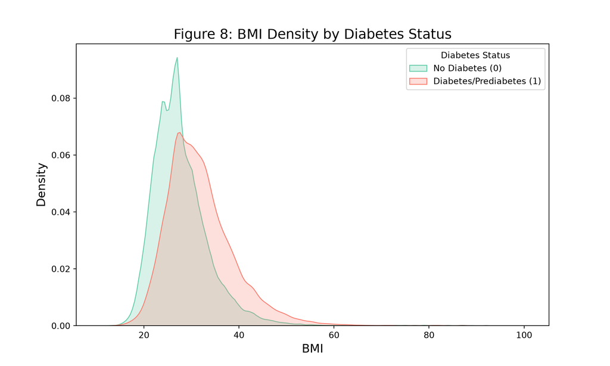

```python
# Set figure size
plt.figure(figsize=(10, 6))

# Ensure Diabetes_binary is integer for filtering and plotting
cdc_data_df["Diabetes_binary"] = cdc_data_df["Diabetes_binary"].astype(int)

# KDE plot for BMI distribution by diabetes status
sns.kdeplot(data=cdc_data_df[cdc_data_df['Diabetes_binary'] == 0]['BMI'],
            label='No Diabetes (0)', color="mediumaquamarine", fill=True)

sns.kdeplot(data=cdc_data_df[cdc_data_df['Diabetes_binary'] == 1]['BMI'],
            label='Diabetes/Prediabetes (1)', color="salmon", fill=True)

# Titles and labels
plt.title('Figure 8: BMI Density by Diabetes Status', fontsize=16)
plt.xlabel('BMI', fontsize=14)
plt.ylabel('Density', fontsize=14)
plt.legend(title='Diabetes Status')

# Show plot
plt.show()
```

A significant portion of individuals with diabetes have BMI values above 30, supporting established links between obesity and diabetes risk. Despite this, there remains substantial overlap between the two groups, indicating that *BMI alone is not a definitive predictor* of diabetes.

These observations reinforce the importance of using *multiple factors* - not just BMI - when modeling diabetes risk.

#### EDA Summary

This Exploratory Data Analysis (EDA) provides a comprehensive overview of the dataset’s structure, distributions, and key correlations. The findings highlight several critical patterns:

Diabetes prevalence is low (13.9%), leading to a class imbalance that may require resampling techniques.

Age, BMI, and high blood pressure are strong risk factors for diabetes.

Socioeconomic factors (income, education) influence health status, supporting the need for targeted interventions.

The next phase involves data preprocessing, feature selection, and model development to enhance predictive performance.

### Modeling and Results

This section explores the performance of the k-Nearest Neighbors (kNN) algorithm for predicting diabetes using the CDC Behavioral Risk Factor Surveillance System dataset. The primary objective was to evaluate how various modeling choices - such as scaling techniques, distance metrics, SMOTE resampling, feature selection, and hyperparameter tuning - impact classification performance, especially for identifying the minority diabetic class.

We tested four distinct kNN configurations, progressively applying different strategies to improve the model:

1. **kNN 1:** Baseline model trained on the imbalanced dataset (original distribution) using Euclidean distance and uniform weights.
2. **kNN 2:** Tuned model with Manhattan distance, distance-based weighting, and RobustScaler to address outliers.
3. **kNN 3:** SMOTE-resampled model using standard preprocessing, to mitigate class imbalance.
4. **kNN 4:** Feature-selected model combining SMOTE and top 12 features (via chi-squared test), along with distance weighting.

Each model was evaluated using accuracy, ROC-AUC, recall, precision, and f1-score, with particular emphasis on recall for the diabetic class, given the critical importance of minimizing false negatives in healthcare applications.

Results from the four configurations are summarized in Table 4, highlighting the effect of different preprocessing and tuning choices on kNN’s ability to detect diabetes accurately and fairly.

#### Data Preprocessing

Preprocessing is a critical step for models like k-Nearest Neighbors (kNN), which rely on distance-based calculations. If features are not properly scaled or class imbalance is not addressed, kNN’s performance - particularly for detecting minority classes - can degrade significantly.

The dataset originally contained 253,680 survey responses with 21 predictor variables and 1 binary outcome (Diabetes_binary). The following preprocessing steps were applied:

```python
import warnings
warnings.filterwarnings("ignore", category=FutureWarning)

# 1. Remove duplicates
cdc_df = cdc_data_df.drop_duplicates()

# Define features and target
X = cdc_df.drop(columns=['Diabetes_binary'])
y = cdc_df['Diabetes_binary']

# Calculate class distribution
class_distribution = (y.value_counts(normalize=True) * 100).round(2)

# Print clean output
print(
    "Class Distribution After Removing Duplicates (%):\n" +
    "\n".join([f"Class {label}: {percent:.2f}%" for label, percent in class_distribution.items()])
)
```

```
Class Distribution After Removing Duplicates (%):
Class 0: 84.71%
Class 1: 15.29%
```

- **Duplicates Removed:**

A total of 24,206 duplicate rows were dropped to reduce bias and redundancy. This cleanup slightly increased the proportion of the diabetic/prediabetic class - from 13.93% to 15.29% - as duplicates were more prevalent in the majority class.

```python
import warnings
warnings.filterwarnings("ignore", category=FutureWarning)

# 2. Separate features and target
X = cdc_df.drop(columns=["Diabetes_binary"])
y = cdc_df["Diabetes_binary"]

# 3. Train-test split (on original data)
X_train, X_test, y_train, y_test = train_test_split(
    X, y, test_size=0.3, random_state=100, stratify=y
)

# 4. Identify continuous features
continuous = ["BMI", "MentHlth", "PhysHlth"]

# 5. Scale continuous features
scaler = StandardScaler()
X_train = X_train.copy()
X_test = X_test.copy()
X_train[continuous] = scaler.fit_transform(X_train[continuous])
X_test[continuous] = scaler.transform(X_test[continuous])

# 6. Apply SMOTE to training set only
X_train_smote, y_train_smote = SMOTE(random_state=42).fit_resample(X_train, y_train)
```

- **Train-Test Split:**

After removing duplicates, the cleaned dataset was split into a training set (70%) and a test set (30%) using stratified sampling to maintain class proportions. This single split is used for all seven models. Scaling, feature selection and SMOTE are fitted on the training set only, and every model is evaluated on the same untouched test set (68,843 observations, 15.29% diabetic).

- **Ordinal Features Retained as Numeric:**

Variables such as Age, Education, Income, and GenHlth were preserved in their original numeric form due to their natural ordinal structure. Converting them to one-hot encoding would have removed meaningful ordering between categories (e.g., income levels or education attainment).

- **Continuous Features Scaled:**

In this shared preprocessing block, the variables BMI, MentHlth, and PhysHlth were standardized using StandardScaler (fitted on the training set) to ensure equal contribution during distance calculations. This version of the data is used by kNN 3; kNN 1 and kNN 2 scale all 21 features with their own scalers, as described below.

- **Class Balancing with SMOTE:**

To mitigate the impact of class imbalance, Synthetic Minority Over-sampling Technique (SMOTE) was applied to the training set. This produced a balanced 50/50 class distribution, enhancing the model’s ability to identify minority-class (diabetic) cases.

The preprocessing pipeline ensured a clean and distance-aware feature space (with a SMOTE-balanced training set for kNN 3) for modeling and evaluation.

#### Training and Evaluating kNN Models

**kNN 1: Baseline Model - Imbalanced Data**

As a baseline, we trained a k-Nearest Neighbors (kNN) classifier on the original dataset without addressing class imbalance. The model used standard hyperparameters: 5 neighbors, Euclidean distance (p=2), and uniform weighting.

```python
# Split original dataset (imbalanced data)
X_train_imbal, X_test_imbal, y_train_imbal, y_test_imbal = train_test_split(
    X, y, test_size=0.3, random_state=100, stratify=y
)

# Scale all features (fit on training data only)
scaler = StandardScaler()
X_train_imbal_scaled = scaler.fit_transform(X_train_imbal)
X_test_imbal_scaled = scaler.transform(X_test_imbal)

# Train KNN on imbalanced dataset
knn_imbal = KNeighborsClassifier(n_neighbors=5, metric='minkowski', p=2)
knn_imbal.fit(X_train_imbal_scaled, y_train_imbal)
```

```
KNeighborsClassifier()
```

```python
# Predictions
y_pred_imbal = knn_imbal.predict(X_test_imbal_scaled)
y_proba_imbal = knn_imbal.predict_proba(X_test_imbal_scaled)[:, 1]

# Evaluate
accuracy_imbal = accuracy_score(y_test_imbal, y_pred_imbal)
roc_auc_imbal = roc_auc_score(y_test_imbal, y_proba_imbal)

# Build classification report
report_text = f"""
KNN (Imbalanced Data) - Accuracy: {accuracy_imbal:.4f}
KNN (Imbalanced Data) - ROC-AUC Score: {roc_auc_imbal:.4f}

Classification Report (Imbalanced Data):
{classification_report(y_test_imbal, y_pred_imbal)}
"""
print(report_text)
```

```
KNN (Imbalanced Data) - Accuracy: 0.8325
KNN (Imbalanced Data) - ROC-AUC Score: 0.7047

Classification Report (Imbalanced Data):
              precision    recall  f1-score   support

           0       0.87      0.95      0.91     58314
           1       0.41      0.21      0.27     10529

    accuracy                           0.83     68843
   macro avg       0.64      0.58      0.59     68843
weighted avg       0.80      0.83      0.81     68843
```

Evaluation was conducted on a hold-out test set that reflects the real-world class distribution:

The model achieved high overall accuracy (83.2%), driven largely by the dominant majority class. However, it performed poorly in identifying diabetic cases, confirming that kNN is sensitive to class imbalance and may overlook minority outcomes without intervention.

**kNN 2: kNN with Robust Scaling on Imbalanced Data**

To explore whether scaling and distance weighting could improve baseline performance, the second kNN model was trained on the same imbalanced dataset with several enhancements.

This configuration used k = 15, Manhattan distance (p=1), and distance-based weighting, allowing closer neighbors to have greater influence. To reduce the impact of outliers in health-related features like BMI, MentHlth, and PhysHlth, RobustScaler was applied to all features (fitted on the training set).

```python
from sklearn.preprocessing import RobustScaler

# Scale all features using RobustScaler (fit on training data only)
scaler = RobustScaler()
X_train_imbal_scaled = scaler.fit_transform(X_train_imbal)
X_test_imbal_scaled = scaler.transform(X_test_imbal)

# Train kNN on imbalanced dataset
knn_scaled_imbalanced = KNeighborsClassifier(
    n_neighbors=15,
    weights='distance',               # Distance-weighted voting
    metric='minkowski',
    p=1                               # Manhattan distance
)
knn_scaled_imbalanced.fit(X_train_imbal_scaled, y_train_imbal)
```

```
KNeighborsClassifier(n_neighbors=15, p=1, weights='distance')
```

```python
# Predictions
y_pred_imbal = knn_scaled_imbalanced.predict(X_test_imbal_scaled)
y_proba_imbal = knn_scaled_imbalanced.predict_proba(X_test_imbal_scaled)[:, 1]

# Evaluate
accuracy_imbal = accuracy_score(y_test_imbal, y_pred_imbal)
roc_auc_imbal = roc_auc_score(y_test_imbal, y_proba_imbal)

# Report
report_text = f"""
kNN (Imbalanced, RobustScaler) - Accuracy: {accuracy_imbal:.4f}
kNN (Imbalanced, RobustScaler) - ROC-AUC Score: {roc_auc_imbal:.4f}

Classification Report:
{classification_report(y_test_imbal, y_pred_imbal)}
"""
print(report_text)
```

```
kNN (Imbalanced, RobustScaler) - Accuracy: 0.8413
kNN (Imbalanced, RobustScaler) - ROC-AUC Score: 0.7518

Classification Report:
              precision    recall  f1-score   support

           0       0.86      0.97      0.91     58314
           1       0.45      0.16      0.23     10529

    accuracy                           0.84     68843
   macro avg       0.65      0.56      0.57     68843
weighted avg       0.80      0.84      0.81     68843
```

Compared to the baseline, this model showed slightly improved accuracy (84.1%) and a better ROC-AUC score (0.75). However, recall for the diabetic class remained low (15.5%), indicating that class imbalance was still a major obstacle, even with enhanced distance metrics and scaling.

**kNN 3: kNN Performance on SMOTE-Resampled Data**

To directly address class imbalance, the training set was resampled using **SMOTE (Synthetic Minority Over-sampling Technique)**, which creates synthetic samples for the minority class, resulting in a balanced 50/50 distribution.

This kNN model used a slightly different configuration from the baseline: k = 10 (increased from 5), Euclidean distance (p=2), and uniform weighting. The test set remained unchanged to simulate real-world deployment conditions with natural class imbalance.

```python
# Train kNN model on SMOTE-resampled training set
knn_smote = KNeighborsClassifier(n_neighbors=10, metric='minkowski', p=2)
knn_smote.fit(X_train_smote, y_train_smote)
```

```
KNeighborsClassifier(n_neighbors=10)
```

```python
# Predict on untouched test set (already scaled)
y_pred_smote = knn_smote.predict(X_test)
y_proba_smote = knn_smote.predict_proba(X_test)[:, 1]

# Evaluate model performance
accuracy = accuracy_score(y_test, y_pred_smote)
roc_auc = roc_auc_score(y_test, y_proba_smote)

# Build classification report
report_text_smote = f"""
KNN (SMOTE-Resampled Training) - Accuracy: {accuracy:.4f}
KNN (SMOTE-Resampled Training) - ROC-AUC Score: {roc_auc:.4f}

Classification Report (Test Set):
{classification_report(y_test, y_pred_smote)}
"""
print(report_text_smote)
```

```
KNN (SMOTE-Resampled Training) - Accuracy: 0.6907
KNN (SMOTE-Resampled Training) - ROC-AUC Score: 0.7331

Classification Report (Test Set):
              precision    recall  f1-score   support

           0       0.92      0.70      0.79     58314
           1       0.28      0.64      0.39     10529

    accuracy                           0.69     68843
   macro avg       0.60      0.67      0.59     68843
weighted avg       0.82      0.69      0.73     68843
```

After resampling, the model achieved 69.1% accuracy and a ROC-AUC of 0.73. Most notably, recall for the minority class jumped to 64%, reflecting SMOTE’s effectiveness in improving detection of diabetic cases.

However, precision dropped to 28%, indicating an increase in false positives - a common trade-off in recall - optimized models.

**kNN 4: kNN with Feature Selection**

To evaluate whether reducing dimensionality could improve model performance, we applied a **Chi-Square feature selection** technique. This method ranks features by their statistical dependency with the target (Diabetes_binary), helping identify those most relevant for classification.

Chi-square scores were computed on the training set only. Based on the scores (shown in Figure 9), the top 12 features were selected for training. These included a mix of continuous and ordinal variables, with continuous features (like BMI, MentHlth, and PhysHlth) scaled using StandardScaler when present.

```python
# Same split as the shared preprocessing block, but unscaled (chi2 needs non-negative values)
X_train_raw, X_test_raw, y_train_fs, y_test_fs = train_test_split(
    X, y, test_size=0.3, random_state=100, stratify=y
)

# Apply Chi-Square feature selection on TRAINING data only
selector = SelectKBest(score_func=chi2, k="all")
selector.fit(X_train_raw, y_train_fs)
```

```
SelectKBest(k='all', score_func=<function chi2 at 0x7a91427e9f80>)
```

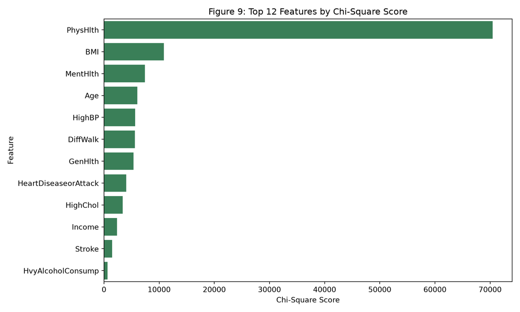

```python
# Store results in DataFrame
chi2_scores = selector.scores_
chi2_results = pd.DataFrame({
    "Feature": X.columns,
    "Chi2 Score": chi2_scores
}).sort_values(by="Chi2 Score", ascending=False)

# Plot top 12 features
plt.figure(figsize=(10, 6))
sns.barplot(x="Chi2 Score", y="Feature", data=chi2_results.head(12), color="seagreen")
plt.title("Figure 9: Top 12 Features by Chi-Square Score")
plt.xlabel("Chi-Square Score")
plt.ylabel("Feature")
plt.tight_layout()
plt.show()
```

The training data was resampled with SMOTE to address class imbalance. The model configuration included: k = 15, Euclidean distance (p=2), and distance-based weighting.

```python
# Get top 12 features (selected on training data)
top_12 = chi2_results.head(12)["Feature"].values
X_train_fs = X_train_raw[top_12].copy()
X_test_fs = X_test_raw[top_12].copy()

# Scale continuous features: fit on train, apply to test
continuous = ["BMI", "MentHlth", "PhysHlth"]
cont_fs = [c for c in continuous if c in X_train_fs.columns]
scaler_fs = StandardScaler().fit(X_train_fs[cont_fs])
X_train_fs[cont_fs] = scaler_fs.transform(X_train_fs[cont_fs])
X_test_fs[cont_fs] = scaler_fs.transform(X_test_fs[cont_fs])

# SMOTE on TRAINING data only
X_train_fs_sm, y_train_fs_sm = SMOTE(random_state=42).fit_resample(X_train_fs, y_train_fs)

# Train kNN (Top 12 features)
knn_fs = KNeighborsClassifier(n_neighbors=15, weights='distance', metric='minkowski', p=2)
knn_fs.fit(X_train_fs_sm, y_train_fs_sm)
```

```
KNeighborsClassifier(n_neighbors=15, weights='distance')
```

```python
# Evaluate on the untouched test set
y_pred_fs = knn_fs.predict(X_test_fs)
y_proba_fs = knn_fs.predict_proba(X_test_fs)[:, 1]

accuracy = accuracy_score(y_test_fs, y_pred_fs)
roc_auc = roc_auc_score(y_test_fs, y_proba_fs)

# Build report
report_text_fs = f"""
kNN (Chi² + SMOTE, Top 12 Features) - Accuracy: {accuracy:.4f}
kNN (Chi² + SMOTE, Top 12 Features) - ROC-AUC Score: {roc_auc:.4f}

Classification Report (Test Set):
{classification_report(y_test_fs, y_pred_fs)}
"""
print(report_text_fs)
```

```
kNN (Chi² + SMOTE, Top 12 Features) - Accuracy: 0.7314
kNN (Chi² + SMOTE, Top 12 Features) - ROC-AUC Score: 0.7220

Classification Report (Test Set):
              precision    recall  f1-score   support

           0       0.91      0.76      0.83     58314
           1       0.30      0.58      0.40     10529

    accuracy                           0.73     68843
   macro avg       0.61      0.67      0.61     68843
weighted avg       0.82      0.73      0.76     68843
```

```python
# Store ROC for later
fpr_fs, tpr_fs, _ = roc_curve(y_test_fs, y_proba_fs)
```

This model reached recall of 0.58 for diabetic cases (precision 0.30, ROC-AUC 0.72). Feature selection reduced the input from 21 to 12 features, with mixed results compared with kNN 3: higher accuracy, PR-AUC and F1, but lower ROC-AUC and recall (kNN 3 and kNN 4 also differ in k and weighting).

#### Comparison of kNN Models with Different Configurations

The first phase of model evaluation focused exclusively on optimizing the k-Nearest Neighbors (kNN) algorithm. Four versions of kNN were trained with varying configurations, including distance metrics, weighting strategies, feature scaling techniques, and class balancing using SMOTE.

Table 4 summarizes the performance of each configuration across key metrics: accuracy, ROC-AUC, precision, recall, and F1-score for the diabetic class (label = 1)

```r
library(kableExtra)

# Create the unified comparison table
knn_models <- data.frame(
  Model = c("kNN 1", "kNN 2", "kNN 3", "kNN 4"),
  k = c(5, 15, 10, 15),
  Distance = c("Euclidean (p=2)", "Manhattan (p=1)", "Euclidean (p=2)", "Euclidean (p=2)"),
  Weights = c("Uniform", "Distance", "Uniform", "Distance"),
  Scaler = c("StandardScaler", "RobustScaler", "StandardScaler", "StandardScaler"),
  SMOTE = c("No", "No", "Yes", "Yes (Feature Selection)"),
  Accuracy = c(0.832, 0.841, 0.691, 0.731),
  ROC_AUC = c(0.705, 0.752, 0.733, 0.722),
  PR_AUC = c(0.281, 0.334, 0.286, 0.300),
  Precision_1 = c(0.406, 0.446, 0.278, 0.303),
  Recall_1 = c(0.206, 0.155, 0.641, 0.579),
  F1_1 = c(0.274, 0.230, 0.388, 0.397)
)

# Display with clean headers
kable(knn_models, format = "html", caption = "Table 4: Performance Comparison of kNN Models") %>%
  kable_styling(full_width = FALSE, bootstrap_options = c("striped", "hover", "condensed")) %>%
  column_spec(1, bold = TRUE)
```

Table 4: Performance Comparison of kNN Models

| Model | k | Distance | Weights | Scaler | SMOTE | Accuracy | ROC_AUC | PR_AUC | Precision_1 | Recall_1 | F1_1 |
| --- | --- | --- | --- | --- | --- | --- | --- | --- | --- | --- | --- |
| kNN 1 | 5 | Euclidean (p=2) | Uniform | StandardScaler | No | 0.832 | 0.705 | 0.281 | 0.406 | 0.206 | 0.274 |
| kNN 2 | 15 | Manhattan (p=1) | Distance | RobustScaler | No | 0.841 | 0.752 | 0.334 | 0.446 | 0.155 | 0.230 |
| kNN 3 | 10 | Euclidean (p=2) | Uniform | StandardScaler | Yes | 0.691 | 0.733 | 0.286 | 0.278 | 0.641 | 0.388 |
| kNN 4 | 15 | Euclidean (p=2) | Distance | StandardScaler | Yes (Feature Selection) | 0.731 | 0.722 | 0.300 | 0.303 | 0.579 | 0.397 |

The four configurations show clear patterns:

- **Configurations without class balancing (kNN 1 and kNN 2)** reached high accuracy (83–84%) but detected only 15–21% of diabetic cases.
- **Configurations trained with SMOTE (kNN 3 and kNN 4)** detected 58–64% of diabetic cases — about three times more — at the cost of lower precision and accuracy.
- **Scaling and distance settings (kNN 2: RobustScaler, Manhattan distance, distance weighting)** gave the best ranking performance among the kNN models (ROC-AUC 0.752 vs. 0.705 for the baseline).
- **Chi-square feature selection (kNN 4)** reduced the input from 21 to 12 features, with mixed results compared with kNN 3: higher accuracy, PR-AUC and F1, but lower ROC-AUC and recall.

In other words, the choice of kNN configuration determines the trade-off between overall accuracy and the detection of diabetic cases. Because several settings changed between configurations, these patterns describe each configuration as a whole rather than the isolated effect of a single setting.

**Selection of kNN 4 for comparison with tree-based models.** kNN 4 was the configuration selected for this comparison in the original 2025 study, and the corrected results support keeping it. Since the priority in a screening context is detecting diabetic cases, the relevant candidates are the SMOTE-trained configurations (kNN 3 and kNN 4). kNN 4 had the highest F1 for the diabetic class among all kNN models (0.397; F1 combines precision and recall), higher accuracy and PR-AUC than kNN 3, and used 12 instead of 21 features. kNN 2 had the highest ROC-AUC (0.752) and kNN 3 the highest recall (0.641).

#### Classifier Comparison: Decision Tree and Random Forest

After evaluating the kNN configurations, we compared kNN 4 (SMOTE + feature selection) to two widely used tree-based classifiers: Decision Tree (DT) and Random Forest (RF). These models were chosen for their strong performance on structured data and their interpretability - key advantages in healthcare applications.

Both DT and RF were trained and evaluated on the same deduplicated training and test sets as the kNN models. The Decision Tree was evaluated both on the original (imbalanced) training data and on a SMOTE-resampled training set; Random Forest was evaluated on the original training data only.

**Decision Tree – Imbalanced dataset**

The Decision Tree classifier was first trained on the original, imbalanced dataset without any resampling or feature selection. This setup mirrors the baseline scenario used in kNN evaluation and allows us to observe how a simple tree-based model handles imbalance on its own.

```python
from sklearn.tree import DecisionTreeClassifier

# Prepare data
X = cdc_df.drop(columns=['Diabetes_binary'])
y = cdc_df['Diabetes_binary']

# Split data
X_train, X_test, y_train, y_test = train_test_split(
    X, y, test_size=0.3, random_state=100, stratify=y
)

# Train Decision Tree
dt_model = DecisionTreeClassifier(max_depth=10, random_state=100)
dt_model.fit(X_train, y_train)
```

```
DecisionTreeClassifier(max_depth=10, random_state=100)
```

```python
# Predict
y_pred = dt_model.predict(X_test)
y_proba_dt = dt_model.predict_proba(X_test)[:, 1]

# Evaluate
accuracy = accuracy_score(y_test, y_pred)
roc_auc = roc_auc_score(y_test, y_proba_dt)

# Build report
report_text_dt = f"""
Decision Tree (Imbalanced) - Accuracy: {accuracy:.4f}
Decision Tree (Imbalanced) - ROC-AUC Score: {roc_auc:.4f}

Classification Report (Test Set):
{classification_report(y_test, y_pred)}
"""
print(report_text_dt)
```

```
Decision Tree (Imbalanced) - Accuracy: 0.8486
Decision Tree (Imbalanced) - ROC-AUC Score: 0.7941

Classification Report (Test Set):
              precision    recall  f1-score   support

           0       0.86      0.97      0.92     58314
           1       0.52      0.15      0.24     10529

    accuracy                           0.85     68843
   macro avg       0.69      0.56      0.58     68843
weighted avg       0.81      0.85      0.81     68843
```

```python
# Store ROC for later
fpr_dt, tpr_dt, _ = roc_curve(y_test, y_proba_dt)
```

Despite high overall accuracy (84.9%), the model struggled to detect diabetic cases, with a recall of just 15% for the minority class.This reinforces the common issue in medical datasets where models optimize for the majority class at the expense of detecting critical minority outcomes.

**Decision Tree – SMOTE-Resampled Dataset**

Next, the Decision Tree model was retrained on a SMOTE-resampled dataset to evaluate whether balancing the classes improves performance.The model architecture was unchanged (max_depth = 10) to ensure a fair comparison with its imbalanced counterpart.

```python
# SMOTE on the training set only; the test set stays untouched
X_train_sm, y_train_sm = SMOTE(random_state=42).fit_resample(X_train, y_train)

# Train Decision Tree on SMOTE data
dt_model_sm = DecisionTreeClassifier(max_depth=10, random_state=100)
dt_model_sm.fit(X_train_sm, y_train_sm)
```

```
DecisionTreeClassifier(max_depth=10, random_state=100)
```

```python
# Predict + evaluate
y_pred = dt_model_sm.predict(X_test)
y_proba_dt_sm = dt_model_sm.predict_proba(X_test)[:, 1]

accuracy = accuracy_score(y_test, y_pred)
roc_auc = roc_auc_score(y_test, y_proba_dt_sm)

# Build report
report_text_dt_sm = f"""
Decision Tree (SMOTE) - Accuracy: {accuracy:.4f}
Decision Tree (SMOTE) - ROC-AUC Score: {roc_auc:.4f}

Classification Report (Test Set):
{classification_report(y_test, y_pred)}
"""
print(report_text_dt_sm)
```

```
Decision Tree (SMOTE) - Accuracy: 0.6706
Decision Tree (SMOTE) - ROC-AUC Score: 0.7555

Classification Report (Test Set):
              precision    recall  f1-score   support

           0       0.93      0.66      0.77     58314
           1       0.28      0.74      0.41     10529

    accuracy                           0.67     68843
   macro avg       0.61      0.70      0.59     68843
weighted avg       0.83      0.67      0.72     68843
```

```python
# Store ROC for later
fpr_dt_sm, tpr_dt_sm, _ = roc_curve(y_test, y_proba_dt_sm)
```

SMOTE significantly improved the model’s ability to identify diabetic cases, as reflected in the jump in recall. While overall accuracy dropped substantially (from 84.9% to 67.1%), this trade-off is often acceptable in medical contexts where minimizing false negatives is critical.

**Random Forest – Imbalanced Dataset**

The Random Forest (RF) classifier was evaluated using the original, imbalanced dataset. As an ensemble of trees, RF is often expected to be more robust than a single model; however, without rebalancing it can still favor the majority class. SMOTE was not applied, as oversampling synthetic data can increase the risk of overfitting in ensemble models.

The model was trained with 200 trees, a maximum depth of 15, and evaluated on the same test set used throughout.

```python
from sklearn.ensemble import RandomForestClassifier

# Train Random Forest
rf_model = RandomForestClassifier(
    n_estimators=200, max_depth=15, random_state=100, n_jobs=-1
)
rf_model.fit(X_train, y_train)
```

```
RandomForestClassifier(max_depth=15, n_estimators=200, n_jobs=-1,
                       random_state=100)
```

```python
# Predict
y_pred = rf_model.predict(X_test)
y_proba_rf = rf_model.predict_proba(X_test)[:, 1]

# Evaluate
accuracy = accuracy_score(y_test, y_pred)
roc_auc = roc_auc_score(y_test, y_proba_rf)

# Build report
report_text_rf = f"""
Random Forest (Imbalanced) - Accuracy: {accuracy:.4f}
Random Forest (Imbalanced) - ROC-AUC Score: {roc_auc:.4f}

Classification Report (Test Set):
{classification_report(y_test, y_pred)}
"""
print(report_text_rf)
```

```
Random Forest (Imbalanced) - Accuracy: 0.8539
Random Forest (Imbalanced) - ROC-AUC Score: 0.8126

Classification Report (Test Set):
              precision    recall  f1-score   support

           0       0.86      0.98      0.92     58314
           1       0.60      0.13      0.22     10529

    accuracy                           0.85     68843
   macro avg       0.73      0.56      0.57     68843
weighted avg       0.82      0.85      0.81     68843
```

```python
# Store ROC for later
fpr_rf, tpr_rf, _ = roc_curve(y_test, y_proba_rf)
```

Random Forest showed the best overall accuracy (85.4%) but, like the basic Decision Tree, it suffered from low recall (13%) for the diabetic class. This highlights a recurring issue: even strong classifiers may underperform on minority classes unless explicitly adjusted for imbalance.

#### Code Implementation Comparison

To consolidate the modeling results, we compared kNN 4 (SMOTE + feature selection) with Decision Tree and Random Forest classifiers.

Table 5 summarizes key performance metrics, while Figure 10 displays ROC curves to visualize the models’ ability to distinguish diabetic from non-diabetic individuals.

```r
library(kableExtra)

# Create the comparison table
model_metrics <- data.frame(
  Model = c("KNN",
            "Decision Tree",
            "Decision Tree",
            "Random Forest"),
  SMOTE = c("Yes (Feature Selection)", "Yes", "No", "No"),
  Accuracy = c(0.731, 0.671, 0.849, 0.854),
  ROC_AUC = c(0.722, 0.756, 0.794, 0.813),
  PR_AUC = c(0.300, 0.317, 0.388, 0.432),
  Precision_1 = c(0.303, 0.281, 0.517, 0.599),
  Recall_1 = c(0.579, 0.740, 0.154, 0.134),
  F1_1 = c(0.397, 0.407, 0.237, 0.219)
)

# Display in unified format
kable(model_metrics, format = "html", caption = "Table 5: Performance Comparison of kNN 4 vs. Tree-Based Models") %>%
  kable_styling(full_width = FALSE, bootstrap_options = c("striped", "hover", "condensed")) %>%
  column_spec(1, bold = TRUE)
```

Table 5: Performance Comparison of kNN 4 vs. Tree-Based Models

| Model | SMOTE | Accuracy | ROC_AUC | PR_AUC | Precision_1 | Recall_1 | F1_1 |
| --- | --- | --- | --- | --- | --- | --- | --- |
| KNN | Yes (Feature Selection) | 0.731 | 0.722 | 0.300 | 0.303 | 0.579 | 0.397 |
| Decision Tree | Yes | 0.671 | 0.756 | 0.317 | 0.281 | 0.740 | 0.407 |
| Decision Tree | No | 0.849 | 0.794 | 0.388 | 0.517 | 0.154 | 0.237 |
| Random Forest | No | 0.854 | 0.813 | 0.432 | 0.599 | 0.134 | 0.219 |

From the comparison:

- *Random Forest* achieved the highest ROC-AUC (0.813) and PR-AUC (0.432), but detected only 13% of diabetic cases at the 0.5 threshold.
- *Decision Tree with SMOTE* achieved the highest recall for the diabetic class (0.740), with ROC-AUC of 0.756.
- *kNN with Feature Selection and SMOTE* reached recall of 0.579 and ROC-AUC of 0.722, below both tree-based models in ranking performance.
- The *non-resampled Decision Tree and Random Forest* models performed well on accuracy and recall for the majority class (non-diabetic), but severely underperformed on recall for diabetic cases (15% and 13%, respectively).

These findings highlight the importance of targeted preprocessing and algorithm tuning when addressing imbalanced healthcare data - especially when the priority is to detect rare but critical conditions like diabetes.

Figure 10 (ROC curves) shows that the tree-based models, especially Random Forest, lie above the kNN curve across most of the range.

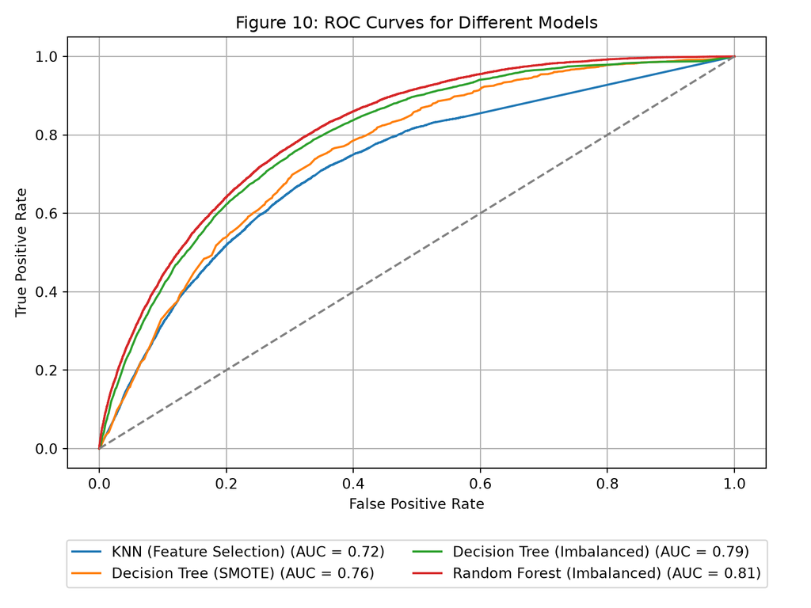

```python
def plot_roc_auc():
    import matplotlib.pyplot as plt

    # Build a clean plot using object-oriented matplotlib
    fig, ax = plt.subplots(figsize=(8, 6))

    # Plot each ROC curve
    ax.plot(fpr_fs, tpr_fs, label=f"KNN (Feature Selection) (AUC = {roc_auc_fs:.2f})")
    ax.plot(fpr_dt_sm, tpr_dt_sm, label=f"Decision Tree (SMOTE) (AUC = {roc_auc_dt_sm:.2f})")
    ax.plot(fpr_dt, tpr_dt, label=f"Decision Tree (Imbalanced) (AUC = {roc_auc_dt:.2f})")
    ax.plot(fpr_rf, tpr_rf, label=f"Random Forest (Imbalanced) (AUC = {roc_auc_rf:.2f})")

    # Add diagonal reference line
    ax.plot([0, 1], [0, 1], linestyle="--", color="gray")

    # Set labels and title
    ax.set_xlabel("False Positive Rate")
    ax.set_ylabel("True Positive Rate")
    ax.set_title("Figure 10: ROC Curves for Different Models")

    # Add legend and grid
    ax.legend(loc="upper center", bbox_to_anchor=(0.5, -0.15), ncol=2, frameon=True)
    ax.grid(True)

    # Render the plot
    plt.tight_layout()
    plt.savefig("roc_curve.png", dpi=300, bbox_inches="tight")
    plt.show()

plot_roc_auc()
```

The ROC curve demonstrates the ability of each model to distinguish diabetic from non-diabetic cases. Random Forest (AUC = 0.81) and Decision Tree (AUC = 0.79) separated diabetic from non-diabetic cases better than kNN with SMOTE and feature selection (AUC = 0.72). kNN remains a simple and interpretable baseline, but on this large dataset the tree-based models achieved higher ROC-AUC.

## Conclusion

This project investigated the behavior and performance of the k-Nearest Neighbors (kNN) algorithm for classifying diabetes using a real-world health dataset of over 253,000 observations. The focus was not only on achieving high accuracy, but on evaluating how model configuration, preprocessing, and resampling affect kNN’s ability to detect the minority (diabetic) class - critical in healthcare contexts where false negatives carry significant risk.

We explored four kNN variations, altering hyperparameters (k, distance metric), scaling techniques, and class balancing via SMOTE. The configurations with SMOTE showed much higher minority-class recall (from about 0.2 to about 0.6). kNN 2 (RobustScaler, Manhattan distance, distance weighting) achieved the best ROC-AUC among the kNN models (0.752). Chi-Square feature selection (kNN 4) reduced the number of features from 21 to 12 with mixed effects on performance.

To contextualize its performance, kNN 4 (SMOTE + feature selection) was compared to two tree-based classifiers: Decision Tree (DT) and Random Forest (RF). Random Forest achieved the highest ROC-AUC (0.813) and PR-AUC (0.432), but its recall for the diabetic class was only 13% at the default threshold. Decision Tree trained on SMOTE achieved the highest recall (0.740). All tree-based models had higher ROC-AUC than every kNN configuration, while kNN 3 and kNN 4 detected more diabetic cases than the Decision Tree and Random Forest trained without SMOTE.

These results highlight a crucial trade-off between accuracy and sensitivity: models trained on imbalanced data reach high accuracy but miss most diabetic cases, while SMOTE improves detection at the cost of precision. Accuracy alone is therefore a poor measure for imbalanced medical data.

In sum, the choice of kNN configuration determines the trade-off between accuracy and the detection of diabetic cases: the configurations trained with SMOTE detected about three times more diabetic cases, and the kNN 2 distance and scaling settings gave the best ranking among kNN models. However, no kNN configuration reached the ROC-AUC of the tree-based models on this large, mostly binary dataset. Beyond the kNN methodology itself, the main lesson of this project is that no single model was best for this task: Random Forest had the highest ROC-AUC, Decision Tree with SMOTE the highest recall, and the SMOTE-trained kNN configurations detected far more diabetic cases than the models trained without balancing. The choice of model and evaluation metric should therefore follow the goal of the analysis — in screening, detecting as many diabetic cases as possible while keeping false alarms acceptable. kNN, a simple and intuitive method that classifies a patient by similar patients, can be a reasonable choice when its configuration is aligned with this goal, but its performance should always be compared with an established benchmark model.

**Methodological revision (2026).** The original 2025 version of this report stated ROC-AUC = 0.88 for kNN 4. A later review by Elena Boiko found that, for kNN 4 and Decision Tree with SMOTE, SMOTE (and for kNN 4 also chi-square selection and scaling) had been applied before the train-test split, so these models were tested on a balanced set containing synthetic records; the tree models had also been evaluated on data with duplicates. In this revision, all preprocessing is fitted on the training data only and all models share one test set. The corrected results are lower and provide a valid estimate of the models’ performance.

## Limitations

The four kNN configurations changed several settings at once (k, scaling, distance metric, weighting, SMOTE, feature selection); the study therefore compares configurations as a whole and does not isolate the effect of each individual setting. Hyperparameters were taken from the original 2025 analysis without systematic cross-validated tuning. The k values were chosen experimentally in 2025 by comparing results on the same test split, so the kNN test results may be slightly optimistic. Standard SMOTE creates fractional values for binary features (SMOTENC would be more appropriate). Precision and recall are reported at the 0.5 threshold. Removing duplicate records changed the share of diabetic cases from 13.93% to 15.29%.

## References

Aggarwal, Charu C et al. 2015. *Data Mining: The Textbook*. Vol. 1. Springer.

Ali, AMEER, MOHAMMED Alrubei, LF Mohammed Hassan, M Al-Ja’afari, and Saif Abdulwahed. 2020. “Diabetes Classification Based on KNN.” *IIUM Engineering Journal* 21 (1): 175–81.

Altamimi, Abdulaziz, Aisha Ahmed Alarfaj, Muhammad Umer, et al. 2024. “An Automated Approach to Predict Diabetic Patients Using KNN Imputation and Effective Data Mining Techniques.” *BMC Medical Research Methodology* 24 (1): 221.

Boateng, Ernest Yeboah, Joseph Otoo, and Daniel A Abaye. 2020. “Basic Tenets of Classification Algorithms k-Nearest-Neighbor, Support Vector Machine, Random Forest and Neural Network: A Review.” *Journal of Data Analysis and Information Processing* 8 (4): 341–57.

Deng, Zhenyun, Xiaoshu Zhu, Debo Cheng, Ming Zong, and Shichao Zhang. 2016. “Efficient kNN Classification Algorithm for Big Data.” *Neurocomputing* 195: 143–48.

Iparraguirre-Villanueva, Orlando, Karina Espinola-Linares, Rosalynn Ornella Flores Castañeda, and Michael Cabanillas-Carbonell. 2023. “Application of Machine Learning Models for Early Detection and Accurate Classification of Type 2 Diabetes.” *Diagnostics* 13 (14): 2383.

Kataria, Aman, and MD Singh. 2013. “A Review of Data Classification Using k-Nearest Neighbour Algorithm.” *International Journal of Emerging Technology and Advanced Engineering* 3 (6): 354–60.

Khateeb, Nida, and Muhammad Usman. 2017. “Efficient Heart Disease Prediction System Using k-Nearest Neighbor Classification Technique.” *Proceedings of the International Conference on Big Data and Internet of Thing*, 21–26.

Mucherino, Antonio, Petraq J Papajorgji, Panos M Pardalos, Antonio Mucherino, Petraq J Papajorgji, and Panos M Pardalos. 2009. “K-Nearest Neighbor Classification.” *Data Mining in Agriculture*, 83–106.

Panwar, Madhuri, Amit Acharyya, Rishad A Shafik, and Dwaipayan Biswas. 2016. “K-Nearest Neighbor Based Methodology for Accurate Diagnosis of Diabetes Mellitus.” *2016 Sixth International Symposium on Embedded Computing and System Design (ISED)*, 132–36.

Saxena, Krati, Zubair Khan, and Shefali Singh. 2014. “Diagnosis of Diabetes Mellitus Using k Nearest Neighbor Algorithm.” *International Journal of Computer Science Trends and Technology (IJCST)* 2 (4): 36–43.

Suriya, S, and J Joanish Muthu. 2023. “Type 2 Diabetes Prediction Using k-Nearest Neighbor Algorithm.” *Journal of Trends in Computer Science and Smart Technology* 5 (2): 190–205.

Syriopoulos, Panos K, Nektarios G Kalampalikis, Sotiris B Kotsiantis, and Michael N Vrahatis. 2023. “K NN Classification: A Review.” *Annals of Mathematics and Artificial Intelligence*, 1–33.

Theerthagiri, Prasannavenkatesan, A Usha Ruby, and J Vidya. 2022. “Diagnosis and Classification of the Diabetes Using Machine Learning Algorithms.” *SN Computer Science* 4 (1): 72.

Uddin, Shahadat, Ibtisham Haque, Haohui Lu, Mohammad Ali Moni, and Ergun Gide. 2022. “Comparative Performance Analysis of k-Nearest Neighbour (KNN) Algorithm and Its Different Variants for Disease Prediction.” *Scientific Reports* 12 (1): 6256.

Zhang, Shichao, Xuelong Li, Ming Zong, Xiaofeng Zhu, and Ruili Wang. 2017. “Efficient kNN Classification with Different Numbers of Nearest Neighbors.” *IEEE Transactions on Neural Networks and Learning Systems* 29 (5): 1774–85.

Zhang, Zhongheng. 2016. “Introduction to Machine Learning: K-Nearest Neighbors.” *Annals of Translational Medicine* 4 (11).